# Practical Machine Learning Course Project

Matthias Reeh

## Introduction

Using devices such as Jawbone Up, Nike FuelBand, and Fitbit it is now possible to collect a large amount of data about personal activity relatively inexpensively. These type of devices are part of the quantified self movement – a group of enthusiasts who take measurements about themselves regularly to improve their health, to find patterns in their behavior, or because they are tech geeks. One thing that people regularly do is quantify how much of a particular activity they do, but they rarely quantify how well they do it. In this project, your goal will be to use data from accelerometers on the belt, forearm, arm, and dumbell of 6 participants. They were asked to perform barbell lifts correctly and incorrectly in 5 different ways. More information is available from the website here: http://web.archive.org/web/20161224072740/http:/groupware.les.inf.puc-rio.br/har (see the section on the Weight Lifting Exercise Dataset).

## Data Preperation

The first step is to load the data sets.

```r
training_data <- read.csv('./pml-training.csv', header = T)
validation_data <- read.csv('./pml-testing.csv', header = T)
```

The next step is to handle missing values.

```r
training_data <- training_data[,-nearZeroVar(training_data)]
na <- sapply(training_data, function(x) mean(is.na(x))) > 0.95
training_data <- training_data[, na==F]
training_data <- training_data[, -(1:6)]
```

Then the data will be separated into a training data set (80%) and a test data set (20%).

```r
inTrain <- createDataPartition(training_data$classe, p=0.8, list = F)
train <- training_data[inTrain,]
test <- training_data[-inTrain, ]
```

## Explorative Data Analysis

To get an better understanding of the dataset a visualization of the corrolation matrix was performed.

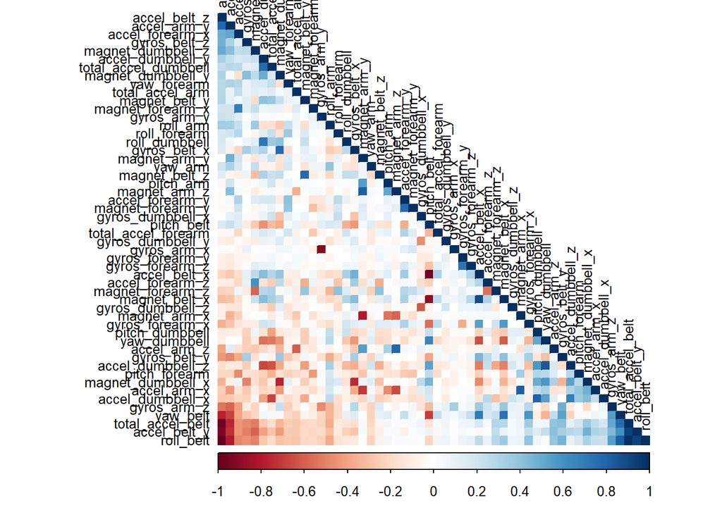

```r
corrolationMatrix <- cor(train[,-which(names(train) == "classe")])
corrplot(corrolationMatrix, order = "FPC", method = "color", type = "lower", tl.cex = 0.8, tl.col = rgb(0, 0, 0))
```

## Modeling

A Random Forest algorithm was used because of its robustness regarding to overfitting as well as to bias. A 3-fold cross validation was used to train the algorithm.

```r
ctrl_rf <- trainControl(method = "cv", number=3, verboseIter=F)

model_rf <- train(classe ~ ., data = train, method= "rf", trControl= ctrl_rf)


model_rf$finalModel
```

```
##
## Call:
##  randomForest(x = x, y = y, mtry = param$mtry)
##                Type of random forest: classification
##                      Number of trees: 500
## No. of variables tried at each split: 2
##
##         OOB estimate of  error rate: 0.57%
## Confusion matrix:
##      A    B    C    D    E class.error
## A 4461    3    0    0    0 0.000672043
## B   15 3017    6    0    0 0.006912442
## C    0   14 2720    4    0 0.006574142
## D    0    0   42 2528    3 0.017489312
## E    0    0    0    3 2883 0.001039501
```

## Evaluation

The model was used to perform a prediction for the test data set to rate the performance of the model.

```r
predict_model_rf <- predict(model_rf, newdata = test)
confMatrix <- confusionMatrix(predict_model_rf, as.factor(test$classe))
accuracy <- confMatrix$overall["Accuracy"]
confMatrix
```

```
## Confusion Matrix and Statistics
##
##           Reference
## Prediction    A    B    C    D    E
##          A 1116    3    0    0    0
##          B    0  755    3    0    0
##          C    0    1  681    9    0
##          D    0    0    0  634    4
##          E    0    0    0    0  717
##
## Overall Statistics
##
##                Accuracy : 0.9949
##                  95% CI : (0.9921, 0.9969)
##     No Information Rate : 0.2845
##     P-Value [Acc > NIR] : < 2.2e-16
##
##                   Kappa : 0.9936
##
##  Mcnemar's Test P-Value : NA
##
## Statistics by Class:
##
##                      Class: A Class: B Class: C Class: D Class: E
## Sensitivity            1.0000   0.9947   0.9956   0.9860   0.9945
## Specificity            0.9989   0.9991   0.9969   0.9988   1.0000
## Pos Pred Value         0.9973   0.9960   0.9855   0.9937   1.0000
## Neg Pred Value         1.0000   0.9987   0.9991   0.9973   0.9988
## Prevalence             0.2845   0.1935   0.1744   0.1639   0.1838
## Detection Rate         0.2845   0.1925   0.1736   0.1616   0.1828
## Detection Prevalence   0.2852   0.1932   0.1761   0.1626   0.1828
## Balanced Accuracy      0.9995   0.9969   0.9963   0.9924   0.9972
```

The accuracy of the prediction is 99.49%. Hence, the out-of-sample error is 0.51%.

## Validation

Finaly the predictions for the validation data set were created.

```r
predict <- predict(model_rf, newdata = validation_data)
```

The figure below shows a visualiziaton of the decision tree.

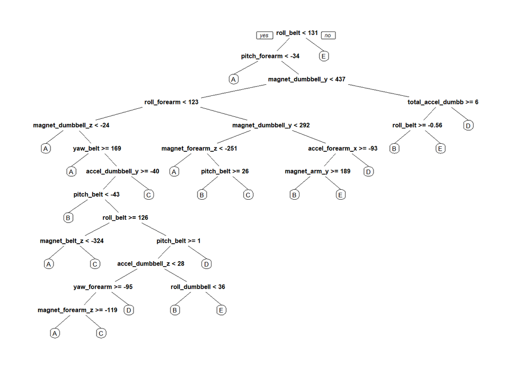

```r
tree <- rpart(classe ~ ., data=train, method="class")
prp(tree)
```